# Approaches to biomedical knowledge

Session #6: Neural networks

Peter N Robinson

## Overview: Neural networks

**Game plan**

This lecture covers a review of artificial neural networks and backpropagation as a prerequisite for understanding transformers and LLMs.

### Part 1: Review

- What is an ANN?
- Forward vs. Reverse pass
- Biomed applications

### Part 2: Architecture and Backprop

- Chain rule & Jacobians
- Vectorized derivatives

### Part 3: Gradients

- Loss functions (MSE)
- Momentum & Adam
- Learning rates

### Part 4: Python

- Full implementation of ANN
- Classify handwritten digits

## ANNs: Overview

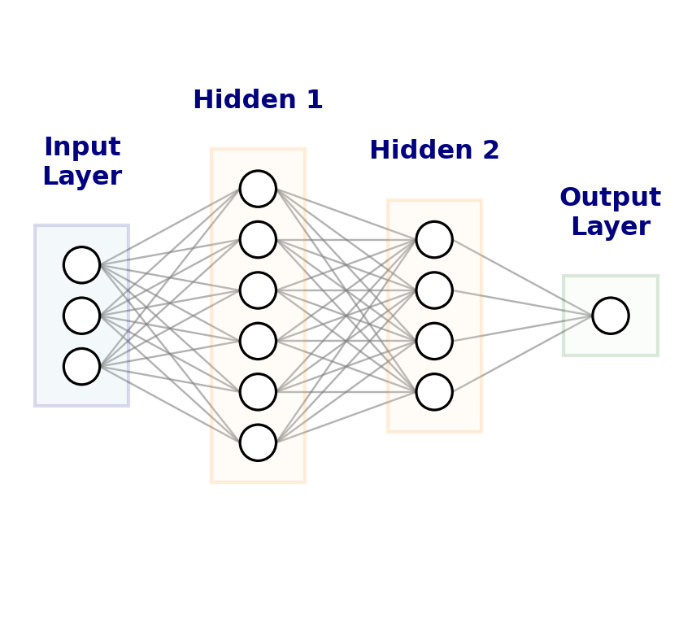

- An artificial neural network (ANN) is a function comprised of neurons, weights, and activation functions
- Neurons are grouped into three main categories of layers:
  - Input layer
  - Hidden layers
  - Output layers
- Naming convention for an N-layer ANN
  - N-1 layers of hidden units
  - 1 output layer
  - In our example, we have a 3-layer ANN

## Neuron

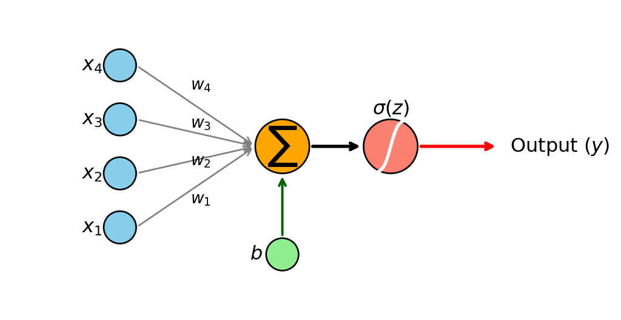

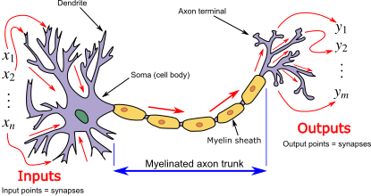

Figure 1

image credit: https://en.wikipedia.org/wiki/Biological_neuron_model

**Neuron**

```
Each neuron receives the weight sum of activations from the previous layer (or the input values) and applies a non-linear activation function
```

- Fully connected layer. In a Feed-Forward Network (FFN), a Fully Connected layer — also known as a **Dense layer** or **Linear layer**—is a layer where every input neuron is connected to every output neuron:
  $$z = \sum_{i=1}^{4} (w_i x_i) + b$$
- A common activation function is the Sigmoid function

$$f(z) = \frac{1}{1 + e^{-z}}$$

## Activation functions

- Activation functions decide whether a neuron should be “fired” (activated) by calculating the weighted sum and adding bias.

### **Sigmoid**

$$\sigma(x) = \frac{1}{1 + e^{-x}}
\tag{1}$$

### **ReLU** (Rectified Linear Unit)

$$f(x) = \max(0, x)
\tag{2}$$

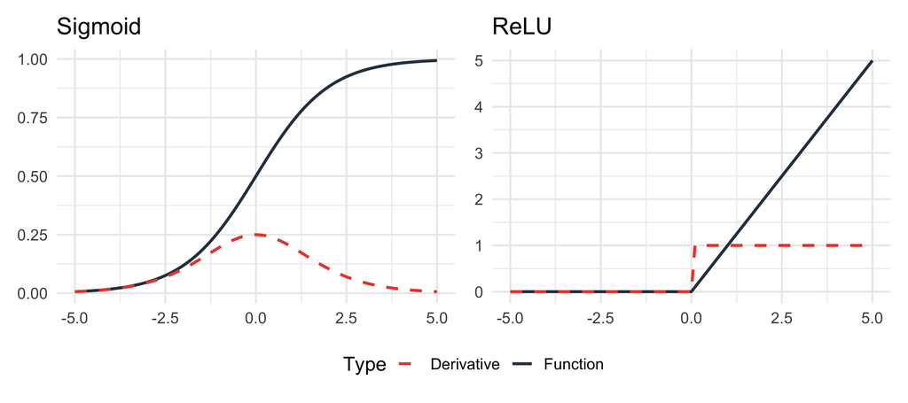

## Representation power

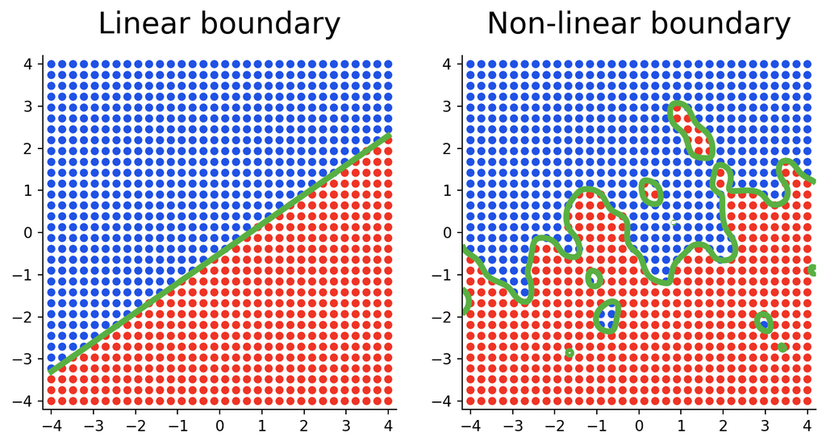

**Approximation**

```
A neural network with at least one hidden layer is a universal approximator in that it can represent any function
```

- The capacity of the ANN increases with more hidden units and more hidden layers<sup>1</sup>
[^1]: Cybenko G (1989) Approximation by superpositions of a sigmoidal function. Mathematics of Control, Signals, and Systems (MCSS)

## Forward pass

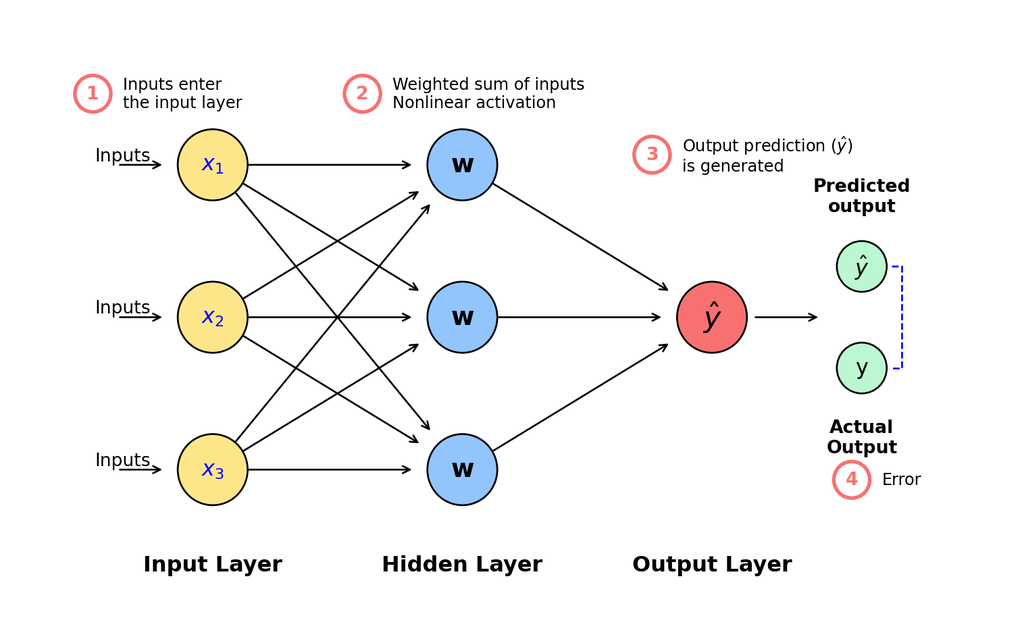

## Backward pass

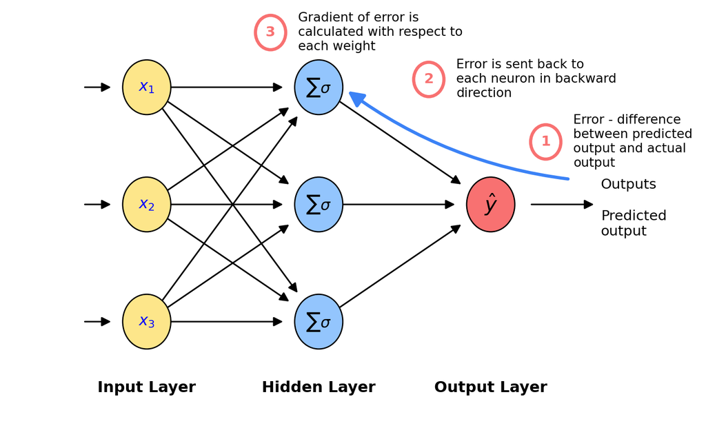

## Applications in bio-medicine

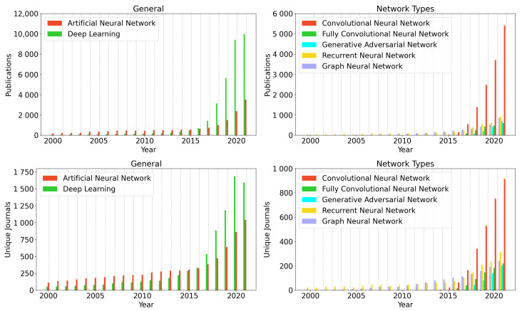

Figure 2: Weiss R, et al (2022) Applications of Neural Networks in Biomedical Data Analysis. Biomedicines. 10(7):1469.

- There is hardly any topic in biomedicine that has not been modeled with ANNs of one type of another
- Deep understanding of the basics of (simple) feed-forward networks is a prerequisite for understanding more sophisticated models in use today

## Overview: Neural networks

**Game plan**

This lecture covers a review of artificial neural networks and backpropagation as a prerequisite for understanding transformers and LLMs.

### Part 1: Review

- What is an ANN?
- Forward vs. Reverse pass
- Biomed applications

### Part 2: Architecture and Backprop

- Chain rule & Jacobians
- Vectorized derivatives

### Part 3: Gradients

- Loss functions (MSE)
- Momentum & Adam
- Learning rates

### Part 4: Python

- Full implementation of ANN
- Classify handwritten digits

## Review: ANN Architecture and Matrix Representation

**Example ANN**

- We will review the architecture of simple ANNs using the classic digit recognition dataset available in `skikit-learn`.
- HOMEWORK We will code a simple ANN to work with this.
- Input: 8x8 grey-scale images of handwritten digits
- Classification goal: Determine which of the digits $0,\ldots, 9$ is represented by the image ($10\times 1$ output vector)

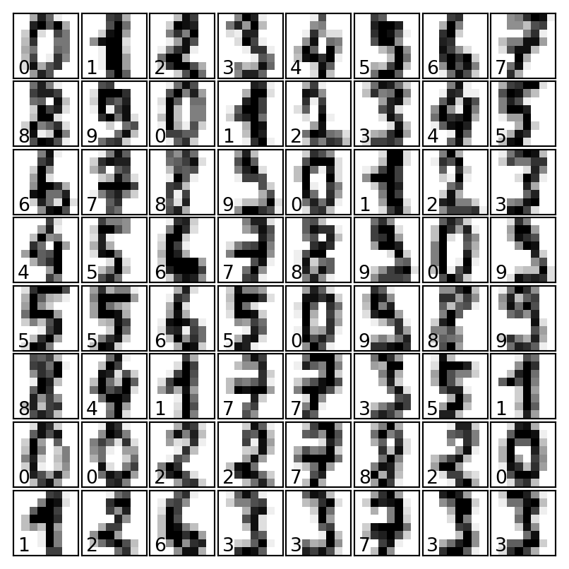

## ANN Architecture

[figure not shown]

## Representing the network using matrices

[figure not shown]

Figure 4: The activation for the first neuron of the first hidden layer is determined by the weighted sum of each of the values in the input; this weighted sum is passed to the sigmoid activation function

- $w_{j,i}$: the **weights**. They are **learnable** parameters
- $z_j$: the **weighted sums** or the **pre-activations**.
- $a_j$: the **activations** and these are passed on as the input to the next layer

$$\begin{bmatrix}
w_{1,1} & w_{1,2} & \cdots & w_{1,64} \\
w_{2,1} & w_{2,2} & \cdots & w_{2,64} \\
& & & \\
\vdots & \vdots & \ddots & \vdots \\
& & & \\
w_{128,1} & w_{128,2} & \cdots & w_{128,64} \\
\end{bmatrix}^{128\times 64}
\begin{bmatrix}
x_1\\
x_2\\
\vdots \\
x_{64}
\end{bmatrix}^{64\times 1}
+
\begin{bmatrix}
b_1\\
b_2\\
\; \\
\vdots \\
\; \\
b_{128}
\end{bmatrix}^{128\times 1}
=
\begin{bmatrix}
z_1\\
z_2\\
\; \\
\vdots \\
\; \\
z_{128}
\end{bmatrix}^{128\times 1}$$

followed by activation

$$\begin{bmatrix}
\sigma(z_1)\\
\sigma(z_2)\\
\; \\
\vdots \\
\; \\
\sigma(z_{128})
\end{bmatrix}^{128\times 1}
=
\begin{bmatrix}
a_1\\
a_2\\
\; \\
\vdots \\
\; \\
a_{128}
\end{bmatrix}^{128\times 1}$$

## The Forward Pass: Step-by-Step

A single ANN layer implements a three-step cycle:

### 1. Weighted Sum ($\mathbf{z}$)

The input vector $\mathbf{x}$ (or activations from the previous layer $\mathbf{a}_{l-1}$) is multiplied by the weight matrix $W$ and the bias vector $\mathbf{b}$ is added.
$$\mathbf{z} = W \mathbf{x} + \mathbf{b}$$

### 2. Activation ($\mathbf{a}$)

A non-linear function $\sigma$ (like Sigmoid or ReLU) is applied element-wise to the pre-activations.
$$\mathbf{a} = \sigma(\mathbf{z})$$

### 3. Propagation

The resulting activation vector $\mathbf{a}$ is output and becomes the incoming input vector for the subsequent layer.

**Summary/Nomenclature**

1. **Input Layer**: Receives raw features $\mathbf{x}$ (e.g., genomic features).
2. **Hidden Layer(s)**:
   - Compute weighted sums of inputs.
   - Apply activation functions to introduce non-linearity.
3. **Output Layer**: Produces the final prediction $\hat{y}$ (e.g., disease risk probability).
4. **Foeward pass**: Perform this three-step forward pass sequentially through all layers to compute the final output.

## Neurons as functions

Each neuron in the hidden layers can be thought of as a function that takes the results of all neurons in the previous layer as input and returns a number between 0 and 1.

The entire network can be thought of as a function that takes 64 numbers as input and returns 10 numbers as output.

## Backpropagation

**Backpropagation**

Backprop is **the** core algorithm behind deep learning.

A key idea of neural nets is to decompose computation into a series of layers, which form modular blocks that can be chained together into a computation graph to perform backprop.

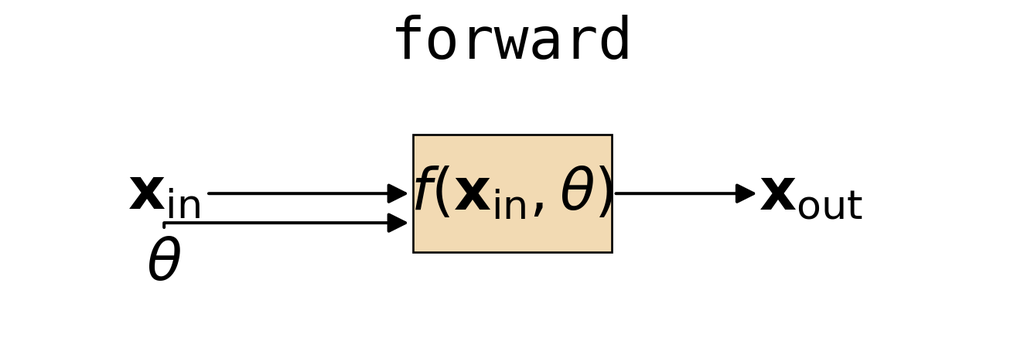

- The forward operation of each layer computes an output based on its input and the current values of the parameters ($\theta$)
- The learning problem is to find the parameters that achieve a desired mapping.
- We do this via gradient descent.

## Backprop: Toy example

- An algorithm that efficiently calculates the gradient of the loss with respect to each parameter in a computation graph.
- In backpropagation, we need to know how the Loss ($L$) changes with respect to the weights.
- We will start off by calculating the backprop by hand with this toy network

## Backprop by hand

- Our network will have a sigmoid activation function in the hidden layer, no activation in the output layer:

$$\sigma(x) = \dfrac{1}{1+e^{-x}}$$

- We will use a squared-error loss function (where $y$ is the label, i.e., zero or one) and $a_3$ is the output of the ANN:
  $$\mathcal{L} = \dfrac{1}{2}(y-a_3)^2$$

## Backprop by hand

### Forward pass equations

- $z_1 = w_1x_1 + w_3x_2 + b_1$
- $a_1 = \sigma(z_1)$
- $z_2 = w_2x_1 + w_4x_2 + b_2$
- $a_2 = \sigma(z_2)$
- $a_3 = w_5a_1 + w_6a_2 + b_3$
- $z_1$ and $z_2$ are intermediate values that form the argument to the activation function
- $x_1$, $x_2$, and $y$ are constants as far as the loss function is concerned. However, the loss will change as a function of the parameters
  $$\mathcal{L} = L(w_1, w_2,w_3, w_4, w_5, w_6, b_1, b_2, b_3; x_1, x_2, y)$$
- Equivalently: $\mathcal{L} = L(\Theta; \mathbf{x};y)$

## Chain rule (review)

- To understand backprop, it is essential to be familiar with the chain rule
- If $f$ and $g$ are differentiable functions, then
  $$\left(f(g(x))\right)^{\prime} = f^{\prime}(g(x))\cdot g^{\prime}(x)$$
- The chain rule can also be written as follows. If $y=f(u)$ and $u=g(x)$, then
  $$\dfrac{dy}{dx} =\dfrac{dy}{du}\dfrac{du}{dx}$$

Examples

- **Power Rule**: $y = (5+3x)^5$
  - Let $u = 5+3x$, so $y = u^5$
  - $\frac{dy}{du} = 5u^4$ and $\frac{du}{dx} = 3$
    $$\frac{dy}{dx} = 5(5+3x)^4 \cdot 3 = 15(5+3x)^4$$
- **Trig**: $y = \sin(4x+3)$
  - Let $u = 4x+3$, so $y = \sin(u)$
  - $\frac{dy}{du} = \cos(u)$ and $\frac{du}{dx} = 4$
    $$\frac{dy}{dx} = \cos(4x+3) \cdot 4 = 4\cos(4x+3)$$

## Calculating partial derivatives

To calculate the gradient of the loss function, $\nabla (\Theta; \mathbf{x};y)$, we need all the partial derivatives – for all weights and biases. Let’s do this step by step

- derivative of the sigmoid activation function
  $$\begin{eqnarray*}
  \dfrac{d\sigma(x)}{dx} =\dfrac{d}{dx} \dfrac{1}{1+e^{-x}} &=&\sigma(x) \cdot \left( 1 -\sigma(x) \right)
  \end{eqnarray*}$$
- Refer to the previous lecture for details of the derivation.
- The forward pass calculates $\sigma(x)$. Using this derivation, the backward pass can calculate the partial derivate **easily** using the value of $\sigma(x)$.

## Derivative of the loss function

- In our toy network, $a_3$ was the output of the network (i.e., the *prediction*).
- $y$ is the true value
- The squared error loss function is thus

$$\mathcal{L}=\dfrac{1}{2}(y-a_3)^2$$

- The first derivative of the loss function with respect to the output is then
  $$\dfrac{\partial \mathcal{L}}{\partial a_3} = 2\cdot \dfrac{1}{2}(y-a_3)\cdot(-1)
  = a_3 - y$$

## How does the loss change as $w_6$ changes?

- We have by the chain rule

$$\dfrac{\partial \mathcal{L}}{\partial w_6} =
\dfrac{\partial \mathcal{L}}{\partial a_3} \cdot \dfrac{\partial a_3}{\partial w_6}$$

- from the above, we had that $\dfrac{\partial \mathcal{L}}{\partial a_3} = a_3 - y$
- we can reuse this value and now just need $\dfrac{\partial a_3}{\partial w_6}$

$$\dfrac{\partial a_3}{\partial w_6}
=
\dfrac{\partial (w_5a_1 + w_6a_2+b_3)}{\partial w_6} = a_2$$

- We have calculate the value of $a_2$ in the forward pass, so this is easy
  $$\dfrac{\partial \mathcal{L}}{\partial w_6} = ( a_3 - y)a_2$$
- Similar logic gets us $\dfrac{\partial \mathcal{L}}{\partial w_5} = ( a_3 - y)a_1$

## How does the loss change as $b_3$ changes?

We have by the chain rule

$$\dfrac{\partial \mathcal{L}}{\partial b_3} = \dfrac{\partial \mathcal{L}}{\partial a_3} \cdot \dfrac{\partial \mathcal{a_3}}{\partial b_3}$$

- Recall that $\dfrac{\partial \mathcal{L}}{\partial a_3} = a_3 - y$
- we can reuse this value and now just need $\dfrac{\partial \mathcal{a_3}}{\partial b_3}$

$$\dfrac{\partial a_3}{\partial b_3}
=
\dfrac{\partial (w_5a_1 + w_6a_2+b_3)}{\partial b_3} = 1$$

- this is easy
  $$\dfrac{\partial \mathcal{L}}{\partial b_3} = ( a_3 - y)\cdot 1 = a_3 - y$$

## How does the loss change as $b_2$ changes?

We have by the chain rule

$$\dfrac{\partial \mathcal{L}}{\partial b_2} = \dfrac{\partial \mathcal{L}}{\partial a_3} \cdot \dfrac{\partial \mathcal{a_3}}{\partial a_2}
\cdot \dfrac{\partial \mathcal{a_2}}{\partial z_2}
\cdot \dfrac{\partial \mathcal{z_2}}{\partial b_2}$$

- We had that $\frac{\partial \mathcal{L}}{\partial a_3} = a_3 - y$
- $a_3 = w_5a_1 + w_6a_2 + b_3$ and thus $\frac{\partial \mathcal{a_3}}{\partial a_2} = w_6$
- $a_2 = \sigma(z_2)$, and so
  $$\dfrac{\partial \mathcal{a_2}}{\partial z_2} = \sigma^{\prime}(z_2) = \sigma(z_2)(1-\sigma(z_2)) = a_2(1-a_2)$$
- $z_2 = w_2x_1 + w_4x_2 + b_2$ and so $\frac{\partial \mathcal{z_2}}{\partial b_2} = 1$
- Putting everything together<sup>1</sup>, we have
  $$\dfrac{\partial \mathcal{L}}{\partial b_2} =
  ( a_3 - y)\cdot w_6 \cdot a_2(1-a_2) \cdot 1$$

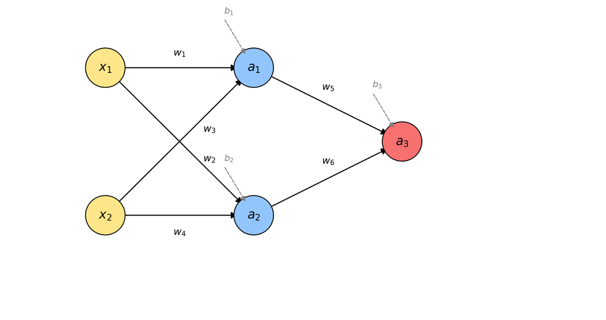

[^2]: Easy! We have the values for $a_3$, $y$, $w_6$, and $a_2$ from the forward pass

## How does the loss change as the other parameters change?

- HOMEWORK You will be asked to derive expressions for $w_1, w_2, w_3, w_4, w_5, b_1, b_2$.
- If we change the network architecture, the activation function, or the loss function, we would need to recalculate these expressions
- This manual procedure is **tedious** and would not scale to exploring various network structures for realistic network sizes.
- We will see it is possible to automate this procedure, but to understand that, we will show how it is possible to use **matrix calculus** to abstract away some of the fidgety work with the indices

## Matrix calculus: Vector function with scalar argument

- We will briefly review matrix calculus before proceeding.
- Consider the function
  $$\mathbf{f}(t) = \begin{bmatrix} t \cos(t) \\ t \sin (t) \\ t \end{bmatrix}$$
- In general, we write such functions as

$$\mathbf{f}(x) = \begin{bmatrix} f_1(x) \\ f_2(x) \\ \vdots \\ f_n(x) \end{bmatrix}$$

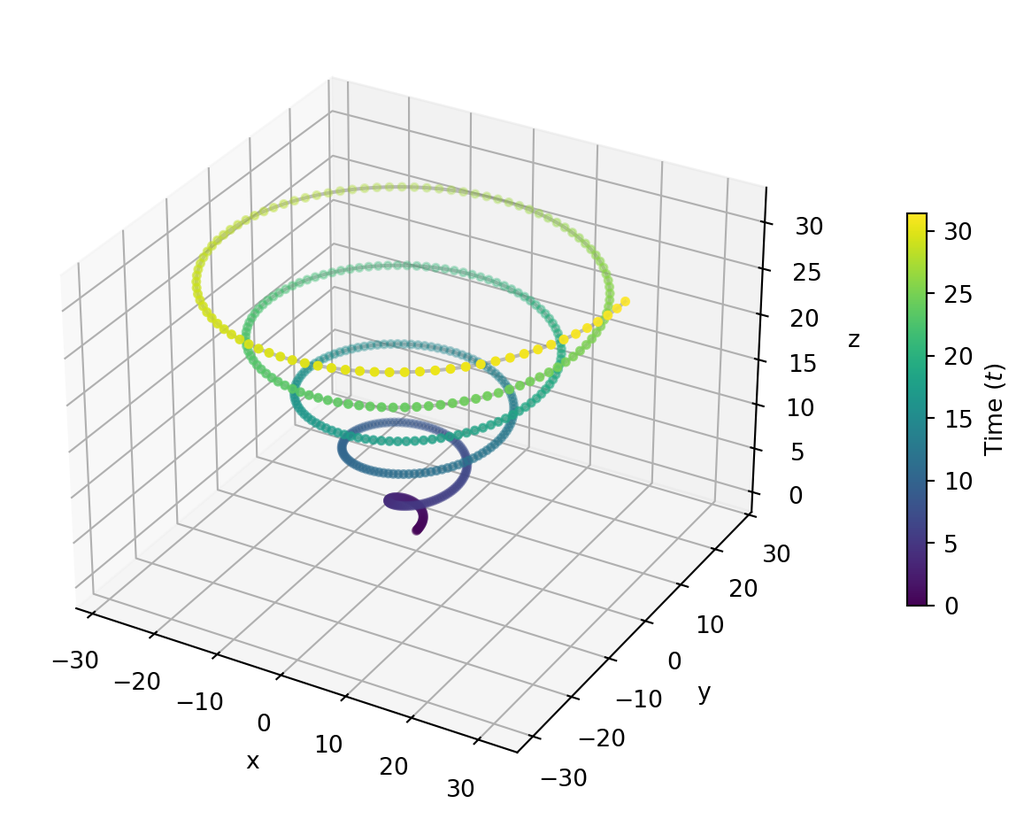

## Tangent vector

**Tangent vector**

The derivative of $\mathbf{f}(t)$ is callled the **tangent vector**. The derivative is defined as the derivative of each of the components of $\mathbf{f}(t)$

- We will use the conventions:
  - lower case normal font: scalar
  - lower-case bold font: vector
  - Uppercase bold font: matrix
- Example

$$\mathbf{f}(x) = \begin{bmatrix} 4x^2-7x +42\\ x^9 -21\end{bmatrix}$$
then
$$\dfrac{\partial \mathbf{f}(x)}{\partial x}
=
\begin{bmatrix} 8x-7 \\9x^8 \end{bmatrix}$$

- Here, $\mathbf{f}$ is bold - the function returns a vector, and $x$ is normal font - the function takes a scalar.

## Matrix calculus: Scalar function with vector argument

**Scalar field**

A function taking a vector argument and returning a scalar is called a **scalar field**: $f: \mathbb{R}^m \rightarrow \mathbb{R}$

In matrix calculus notation<sup>1</sup>, we write
$$\dfrac{\partial f(\mathbf{x})}{\partial \mathbf{x}} =
\begin{bmatrix} \dfrac{\partial f}{\partial x_1} & \dfrac{\partial f}{\partial x_2} & \cdots & \dfrac{\partial f}{\partial x_n} \end{bmatrix}
\tag{4}$$

Another commonly encountered notation is the **gradient**, which by convention is represented as a column vector

$$\nabla f(\mathbf{x}) =
\begin{bmatrix} \dfrac{\partial f}{\partial \mathbf{x}} \end{bmatrix}^T
=
\begin{bmatrix} \dfrac{\partial f}{\partial x_1}\\ \dfrac{\partial f}{\partial x_2} \\ \cdots \\ \dfrac{\partial f}{\partial x_n} \end{bmatrix}
\tag{5}$$

[^3]: We are using the numerator layout, where $\frac{\partial f}{\partial x}$ is written as a **row** vector. The **denominator** layout is also commonly used in machine learning, and $\frac{\partial f}{\partial x}$ would be written as a **column** vector. Obviously it is important to be consistent!

## Matrix calculus: Vector function with vector argument

**Note**

We are calculating $\frac{\partial \mathbf{f}}{\partial \mathbf{x}}$, a function that takes a vector input and returns a vector (the two vectors may or may not have the same dimensions).

The numerator layout convention yields a column vector for the derivative of $\mathbf{f}(x)$ (a function that takes a scalar argument and returns a vector). Correspondingly, if $\mathbf{f}$ is a vector and $\mathbf{x}$ is a vector, the derivative is a matrix where each row corresponds to an element of $\mathbf{f}$ and each column to an element of $\mathbf{x}$.

- For $\mathbf{f}: \mathbb{R}^m \rightarrow \mathbb{R}^n$, the first derivative is called the **Jacobian**:

$$\dfrac{\partial \mathbf{f}(\mathbf{x})}{\partial \mathbf{x}}
=
\begin{bmatrix}
\dfrac{\partial f_1}{\partial x_1} & \dfrac{\partial f_1}{\partial x_2} & \cdots & \dfrac{\partial f_1}{\partial x_m} \\
\dfrac{\partial f_2}{\partial x_1} & \dfrac{\partial f_2}{\partial x_2} & \cdots & \dfrac{\partial f_2}{\partial x_m} \\
\vdots & \vdots & \ddots & \vdots \\
\dfrac{\partial f_n}{\partial x_1} & \dfrac{\partial f_n}{\partial x_2} & \cdots & \dfrac{\partial f_n}{\partial x_m} \\
\end{bmatrix}^{n\times m}
\tag{6}$$

## Matrix calculus: Vector function with vector argument

$$\frac{\partial \mathbf{f}}{\partial \mathbf{x}}
=
\begin{bmatrix}
\dfrac{\partial f_1}{\partial x_1} & \dfrac{\partial f_1}{\partial x_2} & \cdots & \dfrac{\partial f_1}{\partial x_m} \\
\dfrac{\partial f_2}{\partial x_1} & \dfrac{\partial f_2}{\partial x_2} & \cdots & \dfrac{\partial f_2}{\partial x_m} \\
\vdots & \vdots & \ddots & \vdots \\
\dfrac{\partial f_n}{\partial x_1} & \dfrac{\partial f_n}{\partial x_2} & \cdots & \dfrac{\partial f_n}{\partial x_m}
\end{bmatrix}^{n\times m}
\tag{7}$$

$$\frac{\partial \mathbf{f}}{\partial \mathbf{x}}
=
\begin{bmatrix}
\dfrac{\partial f_1}{\partial x_1} & \dfrac{\partial f_1}{\partial x_2} & \cdots & \dfrac{\partial f_1}{\partial x_m} \\
\dfrac{\partial f_2}{\partial x_1} & \dfrac{\partial f_2}{\partial x_2} & \cdots & \dfrac{\partial f_2}{\partial x_m} \\
\vdots & \vdots & \ddots & \vdots \\
\dfrac{\partial f_n}{\partial x_1} & \dfrac{\partial f_n}{\partial x_2} & \cdots & \dfrac{\partial f_n}{\partial x_m}
\end{bmatrix}^{n\times m}
=
\begin{bmatrix}
- \nabla f_1(\mathbf{x})^T - \\
- \nabla f_2(\mathbf{x})^T - \\
\\
\vdots \\
\\
- \nabla f_n(\mathbf{x})^T -
\end{bmatrix}^{n\times m}$$

- We can think of Equation 7 as a stack of transposed gradient vectors (c.f., Equation 5)

## Matrix calculus: Scalar function with matrix argument

- let $f$ be a function that takes an $n\times m$ matrix as input and produces a scalar value
- $f: \mathbb{R}^{n\times m}\rightarrow \mathbb{R}$
- In the Numerator Layout, the rule is that the derivative $\frac{\partial f}{\partial \mathbf{X}}$ should have the shape of the transpose of $\mathbf{X}$.
- If $\mathbf{X}$ is $n \times m$ then $\frac{\partial f}{\partial \mathbf{X}}$ must be $m \times n$

$$\dfrac{\partial f(\mathbf{X})}{\partial \mathbf{X}}
=
\begin{bmatrix}
\frac{\partial f}{\partial x_{11}} & \frac{\partial f}{\partial x_{21}} & \cdots \frac{\partial f}{\partial x_{n1}} \\
\frac{\partial f}{\partial x_{12}} & \frac{\partial f}{\partial x_{22}} & \cdots \frac{\partial f}{\partial x_{n2}} \\
\vdots & \vdots & \ddots & \vdots \\
\frac{\partial f}{\partial x_{1m}} & \frac{\partial f}{\partial x_{2m}} & \cdots \frac{\partial f}{\partial x_{nm}} \\
\end{bmatrix}^{m\times n}
\tag{8}$$

## Matrix calculus: Scalar function with matrix argument

- Similar to our motivation for the dimensions of the derivative of a vector function with vector arguments, we can intuit that the transpose is necessary by comparing to the definition of $\frac{\partial d}{\partial \mathbf{x}}$
- We defined $\frac{\partial d}{\partial \mathbf{x}}$ as a **row** vector, using $\mathbf{x}^T$ as the ordering
- Therefore, consistency demands that the $\dfrac{\partial f}{\partial \mathbf{X}}$ be ordered as $\mathbf{X}^T$

$$\dfrac{\partial f}{\partial \mathbf{x}} =
\begin{bmatrix} \dfrac{\partial f}{\partial x_1} & \dfrac{\partial f}{\partial x_2} & \cdots & \dfrac{\partial f}{\partial x_n} \end{bmatrix}^{1\times n}$$

$f: \mathbb{R}^n \rightarrow \mathbb{R}$ (function takes a vector as input and produces a scalar)

$$\dfrac{\partial f}{\partial \mathbf{X}}
=
\begin{bmatrix}
\frac{\partial f}{\partial x_{11}} & \frac{\partial f}{\partial x_{11}} & \cdots \frac{\partial f}{\partial x_{n1}} \\
\frac{\partial f}{\partial x_{12}} & \frac{\partial f}{\partial x_{22}} & \cdots \frac{\partial f}{\partial x_{n2}} \\
\vdots & \vdots & \ddots & \vdots \\
\frac{\partial f}{\partial x_{1m}} & \frac{\partial f}{\partial x_{2m}} & \cdots \frac{\partial f}{\partial x_{nm}} \\
\end{bmatrix}^{m\times n}$$

- Compare the first row of the matrix with the row vector on the left

## Backpropagation with matrix notation

- Each layer of a fully connected feed forward network (FFN) can be thought of as a vector function $f: \mathbb{R}^n \rightarrow \mathbb{R}^m$:

$$\mathbf{y}^{m\times 1} = \mathbf{f}(\mathbf{x}^{n\times 1})$$

- The input to the layer is an $n$-dimensional vector $\mathbf{x}^{n\times 1}$. This vector is either the actual input to the FFN or (if we are working with a hidden layer), the output of the previous layer.
- The forward pass runs through each layer of the FFN. $\mathbf{y}^{(i)}$ becomes $\mathbf{x}^{(i+1)}$ (output of layer $i$ becomes the input to layer $i+1$)
- The output of the final layer is used to calculate the loss. Letting this layer be called $\mathbf{h}$, we have
  $$\mathcal{L} = L(\mathbf{h}, \mathbf{y}_{true})$$
- The loss $\mathcal{L}$ is a scalar value.
- We need to move this error **back** through the network to perform back propagation

## FFN forward pass in matrix notation

- For layers with an input vector coming from the previous layer, we have
  $$\mathbf{y}^{m\times 1} = \mathbf{W}^{m\times n}\mathbf{x}^{n\times 1} + \mathbf{b}^{m\times 1}$$
- For activation layers, we have
  $$\mathbf{y}^{m\times 1} = \mathbf{\sigma}(\mathbf{x}^{m\times 1} )$$
- In this notation, $\mathbf{\sigma}$ is a vector-valued function (and is shown in bold)

$$\mathbf{\sigma}(\mathbf{x}^{m\times 1} ) =
\begin{bmatrix}
\sigma(x_1) \\
\sigma(x_2) \\
\vdots \\
\sigma(x_m) \\
\end{bmatrix}$$

## Backprop derivatives

- The derivative of the loss function with respect to the network output is the first error term
- To pass this back through the network, we must determine how the error term changes with a change to the input of a layer with respect to how the error changes with respect to the lyers output.
- The following equation is the change in the error given the **output** of the layer

$$\dfrac{\partial E}{\partial \mathbf{y}}$$

- The following equation is the change in the error given the **input** of the layer

$$\dfrac{\partial E}{\partial \mathbf{x}}$$

- We can calculate this using the chain rule

$$\dfrac{\partial E}{\partial \mathbf{x}} = \dfrac{\partial E}{\partial \mathbf{y}} \odot \dfrac{\partial \mathbf{y}}{\partial \mathbf{x}}$$

- But where does the Hadamard product ($\odot$) come from?
- $\odot$ refers to element wise-multiplication
- Let’s review the derivation in the next few slides

## Backprop algorithms

- $\dfrac{\partial E}{\partial \mathbf{x}}$ for layer $i$ becomes $\dfrac{\partial E}{\partial \mathbf{y}}$ for layer $i-1$ as we move back through the FFN

The entire backprop algorithm can be summarized as follows

1. Run a forward pass to map $\mathbf{x}\rightarrow \mathbf{y}$ layer for layer, and get the final output $\mathbf{h}$
2. Calculate the value of the derivative of the loss function using $\mathbf{h}$ and $\mathbf{y}_{true}$. This becomes $\frac{\partial E}{\partial \mathbf{y}}$ for the output layer
3. Repeat for all layers: calculate $\frac{\partial E}{\partial \mathbf{x}}$ from $\frac{\partial E}{\partial \mathbf{y}}$ with $\frac{\partial E}{\partial \mathbf{x}}$ of layer $i$ becoming $\frac{\partial E}{\partial \mathbf{y}}$ for layer $i-1$

## Backprop algorithms: Derivative of activation layer

**Backprop with activation layers**

In general, we can compute this by getting $\frac{\partial E}{\partial \mathbf{y}}$ from the previous layer in our backprop. If the final activation layer produces the output layer, then we need to calculate $\frac{\partial E}{\partial \mathbf{y}}$ based on the specific loss function.

- $\frac{\partial E}{\partial \mathbf{y}}$ is the derivative of the error with respect to the output. This term will depend on the specific loss function. We will see an example in the final section of this lecture.
- In our toy network, we are using the mean squared error (MSE) loss function:
- The cost function for a batch of $n$ samples is the average of individual errors:
  $$E_{batch} = \frac{1}{n} \sum_{i=1}^{n} E_i = \frac{1}{2n} \sum_{i=1}^{n} (y_i - t_i)^2
  \tag{9}$$

The derivative is:
$$\frac{\partial E_{batch}}{\partial \mathbf{y}} = \frac{1}{n} (\mathbf{y} - \mathbf{t})
\tag{10}$$

## The Jacobian of the Activation

- In our example, the final hidden layer is connected to the output via a sigmoid activation function
- Given $\mathbf{y} = \sigma(\mathbf{x})$, the derivative $\frac{\partial \mathbf{y}}{\partial \mathbf{x}}$ is a **Jacobian Matrix**.
- Since $y_i$ only depends on $x_i$ (and no other $x_j$), the matrix is diagonal:

$$\frac{\partial \mathbf{y}}{\partial \mathbf{x}} =
\begin{bmatrix}
\frac{\partial y_1}{\partial x_1} & 0 & \dots \\
0 & \frac{\partial y_2}{\partial x_2} & \dots \\
\vdots & \vdots & \ddots
\end{bmatrix} =
\begin{bmatrix}
\sigma'(x_1) & 0 & \dots \\
0 & \sigma'(x_2) & \dots \\
\vdots & \vdots & \ddots
\end{bmatrix}$$

Recall that:

- **Input vector:** $\mathbf{x} = [x_1, x_2, \dots, x_n]^T$
- **Output vector:** $\mathbf{y} = [\sigma(x_1), \sigma(x_2), \dots, \sigma(x_n)]^T$

Therefore, because the input and output dimensions match ($n = m$), this is a square (and diagonal/symmetrical) matrix.

## Applying the Chain Rule

The gradient of the error $E$ with respect to the input $\mathbf{x}$ is defined by the matrix product of the upstream gradient and the Jacobian:

$$\begin{aligned}
\frac{\partial E}{\partial \mathbf{x}} &= \frac{\partial E}{\partial \mathbf{y}} \cdot \frac{\partial \mathbf{y}}{\partial \mathbf{x}} \\
&= \begin{bmatrix} \frac{\partial E}{\partial y_1} & \dots & \frac{\partial E}{\partial y_m} \end{bmatrix}
\begin{bmatrix} \sigma'(x_1) & \dots & 0 \\ \vdots & \ddots & \vdots \\ 0 & \dots & \sigma'(x_m) \end{bmatrix} \\
&= \begin{bmatrix} \frac{\partial E}{\partial y_1}\sigma'(x_1) & \dots & \frac{\partial E}{\partial y_m}\sigma'(x_m) \end{bmatrix}
\end{aligned}$$

- This matrix multiplication is computationally equivalent to the **Hadamard Product** ($\odot$):

$$\frac{\partial E}{\partial \mathbf{x}} = \frac{\partial E}{\partial \mathbf{y}} \odot \sigma'(\mathbf{x})
\tag{11}$$

**Note**

This identity allows us to skip expensive $O(m^2)$ matrix multiplications in favor of $O(m)$ element-wise operations.

## Backprop algorithms: Derivative of fully connected layer

$$\begin{eqnarray*}
\dfrac{\partial E}{\partial \mathbf{x}} &=&
\dfrac{\partial E}{\partial \mathbf{y}} \dfrac{\partial \mathbf{y}}{\partial \mathbf{x}} \\
&=& \dfrac{\partial E}{\partial \mathbf{y}} \dfrac{\partial \mathbf{Wx+b}}{\partial \mathbf{x}}\\
&=& \dfrac{\partial E}{\partial \mathbf{y}} \dfrac{\partial \mathbf{Wx}}{\partial \mathbf{x}}\\
&=& \mathbf{W}^T\dfrac{\partial E}{\partial \mathbf{y}}
\end{eqnarray*}
\tag{12}$$

- $\mathbf{x}$ is $n\times 1$ (input vector) and $\mathbf{y}$ is $m \times 1$ (output)
- $\frac{\partial E}{\partial \mathbf{y}}$ is a column vector $(m \times 1)$.
- While the Jacobian $\frac{\partial \mathbf{y}}{\partial \mathbf{x}}$ is $\mathbf{W}$ $(m \times n)$, to maintain column-vector notation for the gradient, we must use the transpose $\mathbf{W}^T$ $(n \times m)$^{because of the rules of numerator layout notation.].
- $\frac{\partial E}{\partial \mathbf{x}}$ must be a column vector $(n \times 1)$ to match $\mathbf{x}$.

$$\underbrace{\mathbf{W}^T}_{(n \times m)} \cdot \underbrace{\frac{\partial E}{\partial \mathbf{y}}}_{(m \times 1)} = \underbrace{\frac{\partial E}{\partial \mathbf{x}}}_{(n \times 1)}$$

## Derivative of fully connected layer - derivation

If $\mathbf{y} = \mathbf{Wx} + \mathbf{b}$, then:
$$y_1 = w_{11}x_1 + w_{12}x_2 + \dots + w_{1n}x_n + b_1$$

Taking the derivative of the first output ($y_1$) with respect to the first input ($x_1$):
$$\frac{\partial y_1}{\partial x_1} = w_{11}$$

- Therefore, if we take the derivative of output $i$ ($y_i$) with respect to input $j$ ($x_j$) we get $\frac{\partial y_i}{\partial x_j} = w_{ij}$
- When we fill out the entire matrix, therefore, we get the original weight matrix $\mathbf{W}^{m\times n}$

## Partial derivatives of the bias

- The previous slides told us how to pass the error term backward through the network from layer to layer.
- The goal of backprop is to get first derivatives for tthe bias and weight terms (how would a change in the bias/weight affect the error?) to enable **gradient descent**.
- We need to be able to calculate $\frac{\partial E}{\partial \mathbf{b}}$ and $\frac{\partial E}{\partial \mathbf{W}}$ **given** that we have $\frac{\partial E}{\partial \mathbf{y}}$ and $\frac{\partial E}{\partial \mathbf{x}}$ from previous calculations

$$\begin{eqnarray*}
\dfrac{\partial E}{\partial \mathbf{b}} &=&
\dfrac{\partial E}{\partial \mathbf{y}} \dfrac{\partial \mathbf{y}}{\partial \mathbf{b}} \\
&=& \dfrac{\partial E}{\partial \mathbf{y}} \dfrac{\partial \mathbf{Wx+b}}{\partial \mathbf{b}}\\
&=& \dfrac{\partial E}{\partial \mathbf{y}} (\mathbf{0} + \mathbf{I} )\\
&=& \dfrac{\partial E}{\partial \mathbf{y}}
\end{eqnarray*}
\tag{13}$$

## Partial derivatives of the weights

- $\mathbf{x}^{n\times 1}$: the **input** to the layer
- $\mathbf{W}^{m\times n}$: the **weights** of the layer
- $\mathbf{y}^{m \times 1}$: the **output** of the layer
- $E$ is a scalar ($1 \times 1$): the **error** of the entire network
- The derivative of a scalar $E$ with respect to a vector $\mathbf{y}$ is $\dfrac{\partial E}{\partial \mathbf{y}}$, which is an $m \times 1$ column vector.
- The final result $\frac{\partial E}{\partial \mathbf{W}}$ must be $m \times n$ (to match the shape of the weights for the update rule)
- Derivation of $\frac{\partial \mathbf{Wx+b}}{\partial \mathbf{W}} = \mathbf{x}^T$ is a bit tricky<sup>1</sup>
[^4]: the result is a rank-3 tensor. However, when combined with the incoming gradient $\frac{\partial E}{\partial \mathbf{y}}$ via the chain rule, it collapses neatly into the outer product $\frac{\partial E}{\partial \mathbf{y}}\mathbf{x}^T$.

## Gradient descent

### Part 1: Review

- What is an ANN?
- Forward vs. Reverse pass
- Biomed applications

### Part 2: Architecture and Backprop

- Chain rule & Jacobians
- Vectorized derivatives

### Part 3: Gradients

- Loss functions (MSE)
- Momentum & Adam
- Learning rates

### Part 4: Python

- Full implementation of ANN
- Classify handwritten digits

# Gradient descent

- See the previous lecture for an introduction to gradient descent in the setting of logistic regression.

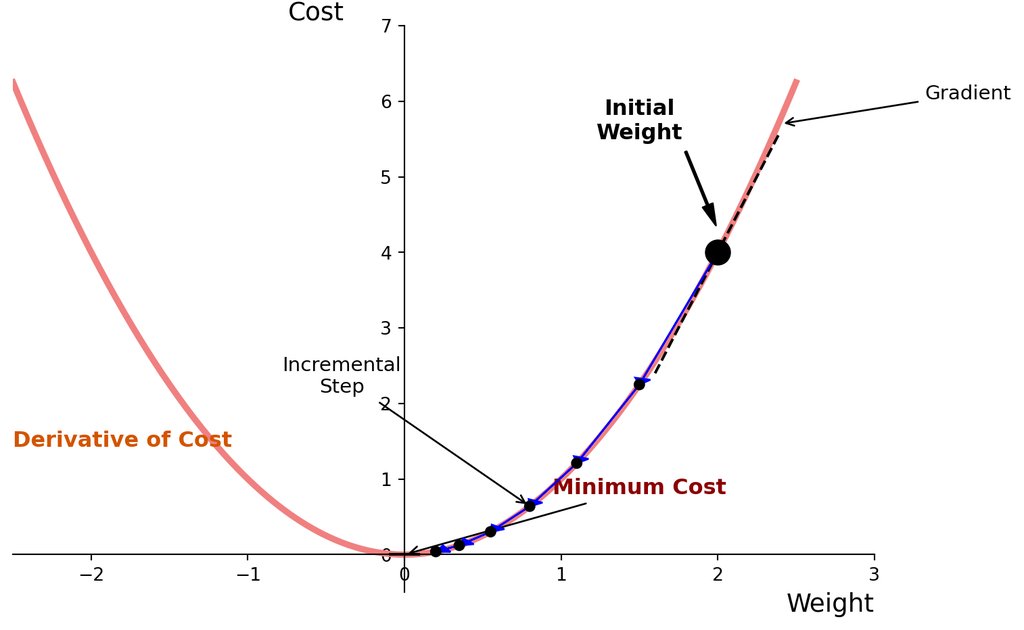

## Stochastic gradient descent

- If we write the loss as

$$\mathcal{L} = L(\Theta; \mathbf{x},y)$$

- This means that we are including **all** training data ($\mathbf{x},y$)
- Gradient descent needs $\frac{\partial L}{\partial \Theta}$, which is obtained by backprop
- **batch training** refers to averaging over all training data
- As the volume of training data increased, it became less sensible to pass all data to the model for each gradient descent step.
- **minibatch training** refers to using a subset of all data for each gradient descent step.
- Because this procedure is noisy compared to full batch training, we refer to it as **stochastic gradient descent** (SGD).
- The noisiness may even be an advantage because it may help avoid falling into local minima
- minibatch size is a hyperparameter, but typically the order of examples is randomized and chunks of data are chosen until all samples have been used.

## Momentum

- If the local landscape includes many local minima, vanilla GD may “get stuck” in a local minimum
- Several procedures have been developed that add a form of **momentum** to the standard GD update rule - this adds inertia to the GD and potentially allows GD to move past local minima.
- Recall that the standard update step is
  $$x \leftarrow x - \eta\dfrac{\partial f}{\partial x}$$
- With momentum, this becomes

$$\begin{eqnarray*}
v &\leftarrow & \mu v- \eta\dfrac{\partial f}{\partial x}\\
x &\leftarrow & x + v
\end{eqnarray*}$$

- for some initial velocity $v$ (usually initialized to zero) and mass $\mu\in \left[0,1\right]$.
- Effectively, this adds back a fraction of the previous step size, which tends to keep things going in the same direction

## Python implementation

**Game plan**

This lecture covers a review of artificial neural networks and backpropagation as a prerequisite for understanding transformers and LLMs.

### Part 1: Review

- What is an ANN?
- Forward vs. Reverse pass
- Biomed applications

### Part 2: Architecture and Backprop

- Chain rule & Jacobians
- Vectorized derivatives

### Part 3: Gradients

- Loss functions (MSE)
- Momentum & Adam
- Learning rates

### Part 4: Python

- Full implementation of ANN
- Classify handwritten digits

## FFN in Python: Dimensions and orientations

- Most FFN software frameworks arrange data in the transposed form.
- In theoretical notation (as in the previous slides of this lecture), we generally use column vectors:
  $$\underbrace{\mathbf{y}}_{m \times 1} = \underbrace{\mathbf{W}}_{m \times n} \underbrace{\mathbf{x}}_{n \times 1} + \underbrace{\mathbf{b}}_{m \times 1}$$
- Frameworks such as **scikit-learn** and **PyTorch** use the transpose (row-major) form:

$$\begin{aligned}
(\mathbf{y})^T &= (\mathbf{W}\mathbf{x} + \mathbf{b})^T \\
\mathbf{y}^T &= (\mathbf{W}\mathbf{x})^T + \mathbf{b}^T \\
\underbrace{\mathbf{y}^T}_{1 \times m} &= \underbrace{\mathbf{x}^T}_{1 \times n} \underbrace{\mathbf{W}^T}_{n \times m} + \underbrace{\mathbf{b}^T}_{1 \times m}
\end{aligned}$$

- This will be relevant for our implementation.

## The Rules of Transposition

To transition between column-vector theory and row-major implementation (like in PyTorch or scikit-learn), we rely on these fundamental properties:

| Rule Name | Mathematical Definition | Logic / Description |
| --- | --- | --- |
| **Sum/Difference** | $(A \pm B)^T = A^T \pm B^T$ | The transpose of a sum is the sum of the transposes. |
| **Product Rule** | $(AB)^T = B^T A^T$ | The order of multiplication **reverses**. This is why $Wx$ becomes $x^T W^T$. |
| **Scalar Rule** | $(\alpha A)^T = \alpha A^T$ | A scalar $\alpha$ is unaffected by the transpose operation. |
| **Involution** | $(A^T)^T = A$ | Transposing a matrix twice returns it to its original form. |
| **Dimensions** | $(m \times n)^T = (n \times m)$ | Rows become columns; columns become rows. |

## From Vectors to Batches in Python

In practice, we rarely compute one sample at a time. We use **batches** to leverage GPU parallelism.

### 1. The “Flat” Array Notation `(n,)`

In NumPy/scikit-learn, a 1D array has the shape `(n,)`.

- It is neither a row nor a column matrix.
- **However**, when you use `dot()` or `@`, Python treats it as a **row vector** by default:
  - $\text{Shape } (n,) \times \text{Shape } (n, m) \rightarrow \text{Shape } (m,)$ is like $\mathbf{x}^{1\times n}\mathbf{W}^{n\times m} \rightarrow \mathbf{y}^{1\times m}$

### 2. Batch Representation (The Design Matrix)

When we move to a batch of $k$ samples, we stack our row vectors $\mathbf{x}^T$ into a **Design Matrix** $\mathbf{X}$.

$$\underbrace{\mathbf{Y}}_{k \times m} = \underbrace{\mathbf{X}}_{k \times n} \underbrace{\mathbf{W}^T}_{n \times m} + \underbrace{\mathbf{b}^T}_{1 \times m}$$

**Broadcasting the Bias**

Note that $\mathbf{b}^T$ is $1 \times m$, but $\mathbf{Y}$ is $k \times m$. Python uses **broadcasting** to automatically “stretch” the bias vector so it is added to every single row in the batch.

## FFN in Python

**Toy FFN**

To help illustrate the concepts in this lecture, we close with the demonstration of a toy Python implementation we will use to predict the identity of hand-written digits

- Let’s begin with the encoding of our activation function (sigmoid; See Equation 1). We want the function to accept an $n\times 1$ vector as input and to return a vector of the same size

```python
def sigmoid(x: npt.NDArray[np.float64]) -> npt.NDArray[np.float64]:
    """Computes the sigmoid of x (our activation function)."""
    return 1.0 / (1.0 + np.exp(-x))
```

- The datatype of the argument is NumPy (`np.float64`). Therefore, the function is **vectorized**. If the argument is a scalar (single number), it returns a single number; if the argument is a vector, it returns a vector of the same dimension and applies the same function to each element of the vector.
- HOMEWORK Write similar functions for `sigmoid_prime` (the first derivative), `mse` (mean-squared error), and `mse_prime`(first derivative of the mse)

## FFN in Python (2)

- We use a class called `Network` to keep track of everything

```python
Layer = typing.Union[FullyConnectedLayer, ActivationLayer]
ArrayOfFloats = npt.NDArray[np.float64]

class Network:
    def __init__(self, verbose=True):
        self.verbose = verbose
        self.layers = []

    def add(self, layer: Layer) -> None:
        self.layers.append(layer)

    def predict(self, input_data: ArrayOfFloats) -> typing.List[ArrayOfFloats]:
        result = []
        for i in range(input_data.shape[0]):
            output = input_data[i]
            for layer in self.layers:
                output = layer.forward(output)
            result.append(output)
        return result

    def fit(self,  x_train,  y_train, minibatches, learning_rate, batch_size) -> None:
        # see following slides!
```

- Let’s start by examining the `predict` method. It takes an array of floats (in our case, this is a vector with dimension $64\times 1$ that represents one image), and it returns an array of float (this is a vector with dimension $10\times 1$ that represents the predicted probabilities for the class of the image)

## The classification task

- Let’s understand what we are trying to predict
- We are using the sklearn digits dataset
- Images of handwritten digits $0,\ldots, 9$
- Our task is to predict which digit is represented by an image

```python
import numpy as np
import numpy.typing as npt
from sklearn import datasets
import typing
import matplotlib.pyplot as plt
import numpy as np
from sklearn import datasets
from sklearn.model_selection import train_test_split
import matplotlib.pyplot as plt

digits = datasets.load_digits()
first_digit = digits.data[0] # type: ignore
first_digit
```

```
array([ 0.,  0.,  5., 13.,  9.,  1.,  0.,  0.,  0.,  0., 13., 15., 10.,
       15.,  5.,  0.,  0.,  3., 15.,  2.,  0., 11.,  8.,  0.,  0.,  4.,
       12.,  0.,  0.,  8.,  8.,  0.,  0.,  5.,  8.,  0.,  0.,  9.,  8.,
        0.,  0.,  4., 11.,  0.,  1., 12.,  7.,  0.,  0.,  2., 14.,  5.,
       10., 12.,  0.,  0.,  0.,  0.,  6., 13., 10.,  0.,  0.,  0.])
```

## Digits dataset

- The first original image is a zero and looks like this:

[figure not shown]

```python
target0 = digits.target[0] # type: ignore
print(f"Class of the first image: '{target0}'")
```

```
Class of the first image: '0'
```

## Preparing the dataset

- We need to reshape the input data to conform to Python conventions.
- Let us first examine the shape of the original data from sklearn

```python
print(f"Shape of digits: '{digits.data.shape}'")
print(f"Shape of an element: '{digits.data[0].shape}'")
```

```
Shape of digits: '(1797, 64)'
Shape of an element: '(64,)'
```

- We have 1797 examples of input data points that have a dimension of 64

```python
X = digits.data.reshape(-1, 1, 64)
print(f"Shape of X: '{X.shape}'")
print(f"Shape of an element: '{X[0].shape}'")
```

```
Shape of X: '(1797, 1, 64)'
Shape of an element: '(1, 64)'
```

- We have transformed the elements of `X` from `(64,)` into `(1, 64)`, i.e., a row vector with 64 columns, to work with numpy

## Preparing the dataset

```python
y = digits.target # type: ignore
print(f"Shape of y: '{y.shape}'")
print("First ten values of y:")
print(y[:10])
```

```
Shape of y: '(1797,)'
First ten values of y:
[0 1 2 3 4 5 6 7 8 9]
```

- Currently, the vector y contains the actual digit we are trying to predict.
- The output of our network will be a ten-element vector with probabilities for $0,\ldots, 9$
- It is convenient to code the predicted values using one-hot encode to simplify the calculation of loss
- One-Hot Encoded (e.g., 3 becomes [0,0,0,1,0,0,0,0,0,0] and 0 becomes [1,0,0,0,0,0,0,0,0,0])

```python
from sklearn.preprocessing import OneHotEncoder
enc = OneHotEncoder()
y_reshaped = enc.fit_transform(y.reshape(-1, 1)).toarray()
print("first element of y_reshaped")
print(y_reshaped[0])
```

```
first element of y_reshaped
[1. 0. 0. 0. 0. 0. 0. 0. 0. 0.]
```

## Test/Training split

```python
X_train, X_test, y_train, y_test = train_test_split(X, y_reshaped, test_size=0.2, random_state=42)

print(f"Training set size: {X_train.shape[0]}")
print(f"Testing set size: {X_test.shape[0]}")
```

```
Training set size: 1437
Testing set size: 360
```

- Setting up the network. HOMEWORK Examine the code, explore effects of different network configurations.
- We will return to the fit method subsequently, but we will start by examine the predict method (which runs the trained network on a new example)

```python
network = Network()
network.add(FullyConnectedLayer(64, 128))
network.add(ActivationLayer())
network.add(FullyConnectedLayer(128, 64))
network.add(ActivationLayer())
network.add(FullyConnectedLayer(64, 10))
network.add(ActivationLayer())

network.fit(X_train, y_train, minibatches=40000, learning_rate=0.5)
```

## Predict

If we run the following code to predict the class of a single example

```python
xt = X_test[0]
out = network.predict(xt)
print(out)
print(y_test[0])
```

We obtain

```
[array([[1.07617827e-03, 9.50165598e-04, 6.77312110e-04, 2.18282629e-04,
        3.00226634e-03, 5.60243267e-04, 9.97963158e-01, 9.64276212e-05,
        1.48108902e-03, 6.76962776e-07]])]
[0. 0. 0. 0. 0. 0. 1. 0. 0. 0.]
```

## Predict (Fully connected layer)

- Let’s carefully examine the predict method

```python
 def predict(self, input_data: ArrayOfFloats) -> typing.List[ArrayOfFloats]:
    result = []
    for i in range(input_data.shape[0]):
        output = input_data[i]
        for layer in self.layers:
            output = layer.forward(output)
        result.append(output)
    return result
```

- `input_data` is an np.ndarray with shape `(1, 64)`, i.e., a row vector
- `output = input_data[i]` means that `output` has shape `(64,)` (also a row vector)
- We iterate through the layers.
- For instance, the first layer was created by `FullyConnectedLayer(64, 128)`

```python
def forward(self, input_data: npt.NDArray[np.float64]) -> npt.NDArray[np.float64]:
    self.input = input_data
    return np.dot(self.input, self.weights) + self.bias
```

- `self.weights` is a matrix with shape `(64, 128)` and and `self.bias` has shape `(1,128)` (and the `input_data` argument to this function was the output from the calling code, i.e., `(64,)`, a row vector)
- The call to `np.dot` returns a vector with shape `(1,128)`.

$$\mathbf{z}^{1\times 128} = \mathbf{x}^{1,64} W^{64, 128} + \mathbf{b}^{1\times 128}$$

## Predict (Activation layer)

- The predict method now iterates to the next layer, which we initiated as `ActivationLayer()`

```python
 def predict(self, input_data: ArrayOfFloats) -> typing.List[ArrayOfFloats]:
    result = []
    for i in range(input_data.shape[0]):
        output = input_data[i]
        for layer in self.layers:
            output = layer.forward(output)
        result.append(output)
    return result
```

The `forward`method of this class is as follows:

```python
def forward(self, input_data: npt.NDArray[np.float64]) -> npt.NDArray[np.float64]:
    self.input = input_data
    return sigmoid(input_data)
```

- Our `input_data` (which is the output of the previous fully connected layer) has shape `(1,128)`.
- As mentioned, the `sigmoid` function is vectorized and returns an array of the same shape `(1,128)`.

## Making the actual prediction

```python
out = network.predict(X_test)
cm = np.zeros((10,10), dtype="uint32")
for i in range(len(y_test)):
    # Convert the One-Hot ground truth back to an integer (0-9)
    true_label = np.argmax(y_test[i])
    # Convert the network output (probabilities) to an integer (0-9)
    predicted_label = np.argmax(out[i])
    cm[true_label, predicted_label] += 1
print()
print(np.array2string(cm))
print()
print("Accuracy = %0.7f" % (np.diag(cm).sum() / cm.sum()))

[[33  0  0  0  0  0  0  0  0  0]
 [ 0 28  0  0  0  0  0  0  0  0]
 [ 0  0 33  0  0  0  0  0  0  0]
 [ 0  0  0 33  0  1  0  0  0  0]
 [ 0  0  0  0 46  0  0  0  0  0]
 [ 0  0  0  0  0 45  1  0  0  1]
 [ 0  0  0  0  0  1 34  0  0  0]
 [ 0  0  0  0  0  0  0 33  0  1]
 [ 0  0  0  0  0  1  0  0 29  0]
 [ 0  0  0  0  0  0  0  0  1 39]]

Accuracy = 0.9805556
```

## Making the actual prediction

```python
out = network.predict(X_test)
```

- In this case, `X_test`has shape `(360,1,64)`, i.e., there are 360 examples

```python
ArrayOfFloats = npt.NDArray[np.float64]
def predict(self, input_data: ArrayOfFloats) -> typing.List[ArrayOfFloats]:
    result = []
    for i in range(input_data.shape[0]):
        output = input_data[i]
        for layer in self.layers:
            output = layer.forward(output)
        result.append(output)
    return result
```

In our first example, `input_data.shape[0]` was 1. For the combined data, it is 360. - The remaining steps are performed 360 times (basically the same as before) - `out` now becomes a list of 360 elements, each of with is a `(1,10)` vector as before.

## Backprop

- Now let us examine the `fit` method, which trains the network using back propagation

```python
Layer = typing.Union[FullyConnectedLayer, ActivationLayer]
ArrayOfFloats = npt.NDArray[np.float64]
def fit(self,  x_train: ArrayOfFloats, y_train: npt.NDArray[np.float64],
        minibatches: int,  learning_rate: float, batch_size: int=64) -> None:
    for i in range(minibatches):
        idx = np.argsort(np.random.random(x_train.shape[0]))[:batch_size]
        x_batch = x_train[idx]
        y_batch = y_train[idx]
        for j in range(batch_size):
            output = x_batch[j]
            for layer in self.layers:
                output = layer.forward(output)
            error = mse_prime(y_batch[j], output)
            for layer in reversed(self.layers):
                error = layer.backward(error)
        for layer in self.layers:
            layer.step(learning_rate)
```

- We will examine this step by step

## Minibatches

```python
Layer = typing.Union[FullyConnectedLayer, ActivationLayer]
ArrayOfFloats = npt.NDArray[np.float64]
def fit(self,  x_train: ArrayOfFloats, y_train: npt.NDArray[np.float64],
        minibatches: int,  learning_rate: float, batch_size: int=64) -> None:
    for i in range(minibatches):
        idx = np.argsort(np.random.random(x_train.shape[0]))[:batch_size]
        x_batch = x_train[idx]
        y_batch = y_train[idx]
        for j in range(batch_size):
            output = x_batch[j]
            for layer in self.layers:
                output = layer.forward(output)
            error = mse_prime(y_batch[j], output)
            for layer in reversed(self.layers):
                error = layer.backward(error)
        for layer in self.layers:
            layer.step(learning_rate)
```

- `X_train` has shape `(1437, 1, 64)`, i.e., 1437 examples. Correspondingly, `y_train` has the same number of expected outcomes coding unsing one-hot vectors : `(1437, 10)`
- **line 6**: `idx` is a row vector, i.e., `(64,)` of randomly chosen indices for the current minibatch
- **line 7**: `x_batch` has shape `(64, 1, 64)`,
- **line 8**: `y_batch` has share `(64,10)`
- **line 9**: We now iterate through each of the examples of the minibatch

## Forward pass

```python
Layer = typing.Union[FullyConnectedLayer, ActivationLayer]
ArrayOfFloats = npt.NDArray[np.float64]
def fit(self,  x_train: ArrayOfFloats, y_train: npt.NDArray[np.float64],
        minibatches: int,  learning_rate: float, batch_size: int=64) -> None:
    for i in range(minibatches):
        idx = np.argsort(np.random.random(x_train.shape[0]))[:batch_size]
        x_batch = x_train[idx]
        y_batch = y_train[idx]
        for j in range(batch_size):
            output = x_batch[j]
            for layer in self.layers:
                output = layer.forward(output)
            error = mse_prime(y_batch[j], output)
            for layer in reversed(self.layers):
                error = layer.backward(error)
        for layer in self.layers:
            layer.step(learning_rate)
```

- **lines 10-12**: This snippet of code performs the forward just like with `predict`

## Gradient of error with respect to output

```python
Layer = typing.Union[FullyConnectedLayer, ActivationLayer]
ArrayOfFloats = npt.NDArray[np.float64]
def fit(self,  x_train: ArrayOfFloats, y_train: npt.NDArray[np.float64],
        minibatches: int,  learning_rate: float, batch_size: int=64) -> None:
    for i in range(minibatches):
        idx = np.argsort(np.random.random(x_train.shape[0]))[:batch_size]
        x_batch = x_train[idx]
        y_batch = y_train[idx]
        for j in range(batch_size):
            output = x_batch[j]
            for layer in self.layers:
                output = layer.forward(output)
            error = mse_prime(y_batch[j], output)
            for layer in reversed(self.layers):
                error = layer.backward(error)
        for layer in self.layers:
            layer.step(learning_rate)
```

- **lines 13**: This function calculates the first derivative of the squared error.
- See Equation 10
- In our toy implementation, we are doing one example at a time and accumulate the error within the `FullyConnectedLayer` class to be able to perform gradient descent
- - HOMEWORK You will code `mse_prime` function.

## Backprop

```python
Layer = typing.Union[FullyConnectedLayer, ActivationLayer]
ArrayOfFloats = npt.NDArray[np.float64]
def fit(self,  x_train: ArrayOfFloats, y_train: npt.NDArray[np.float64],
        minibatches: int,  learning_rate: float, batch_size: int=64) -> None:
    for i in range(minibatches):
        idx = np.argsort(np.random.random(x_train.shape[0]))[:batch_size]
        x_batch = x_train[idx]
        y_batch = y_train[idx]
        for j in range(batch_size):
            output = x_batch[j]
            for layer in self.layers:
                output = layer.forward(output)
            error = mse_prime(y_batch[j], output)
            for layer in reversed(self.layers):
                error = layer.backward(error)
        for layer in self.layers:
            layer.step(learning_rate)
```

- **line 14**: Iterate backwards through each of the layers that we defined (See Network Setup slide)
- **line 15**: Calls the backward method on each of the layers
- We will explain the implementation of the backward method for activation and fully-connected layers in the following slides

## Back: Activation

This is the full class for the Activation Layer

```python
class ActivationLayer:
    input: typing.Optional[npt.NDArray[np.float64]]

    def forward(self, input_data: npt.NDArray[np.float64]) -> npt.NDArray[np.float64]:
        self.input = input_data
        return sigmoid(input_data)

    def backward(self, output_error: npt.NDArray[np.float64]) -> npt.NDArray[np.float64]:
        return sigmoid_prime(self.input) * output_error # type: ignore (We know self.input will be npt.NDArray[np.float64]

    def step(self, eta: float) -> None:
        return
```

- Class definition of an `Activation` layer
- The `forward` pass stores the input data vector and returns the sigmoid activation of that vector
- The `backward pass returns the first derivative of the sigmoid function on the stored`input_data`and multiplies it by the`output_error` that it receives as an argument
- This is an implementation of Equation 11, where the `output_error` is $\frac{\partial E}{\partial \mathbf{y}}$
  $$\frac{\partial E}{\partial \mathbf{x}} = \frac{\partial E}{\partial \mathbf{y}} \odot \sigma'(\mathbf{x})$$
- Does nothing, as there are no weights in the sigmoid function that could be updated by backprop. {.fragment}

## Back: Fully connected

```python
for layer in reversed(self.layers):
    error = layer.backward(error)
```

- $\frac{\partial E}{\partial \mathbf{x}}$ from the activation layer becomes $\frac{\partial E}{\partial \mathbf{y}}$ for the Fully Connected Layer that is called on the next (reversed) iteration
- The `error` that was returned from activation layer had a dimension of $1\times 10$; this is passed to the `layer.backward` method in the next iteration.

```python
class FullyConnectedLayer:
    weights: npt.NDArray[np.float64]
    bias: npt.NDArray[np.float64]
    delta_w: npt.NDArray[np.float64]
    delta_b: npt.NDArray[np.float64]
    passes: int
    input: typing.Optional[npt.NDArray[np.float64]]

    def __init__(self, input_size: int, output_size: int):
        (... omitted ...)

    def forward(self, input_data: npt.NDArray[np.float64]) -> npt.NDArray[np.float64]:
        (... omitted ...)

    def backward(self, output_error: npt.NDArray[np.float64]) -> npt.NDArray[np.float64]:
        input_error = np.dot(output_error, self.weights.T)
        weights_error = np.dot(self.input.T, output_error) # type: ignore (We know self.input will be npt.NDArray[np.float64]

        #  accumulate the error over the minibatch
        self.delta_w += weights_error
        self.delta_b += output_error
        self.passes += 1
        return input_error

    def step(self, eta: float) -> None:
       (... omitted ...)
```

## backward method of `FullyConnectedLayer`

```python
def backward(self, output_error: npt.NDArray[np.float64]) -> npt.NDArray[np.float64]:
    input_error = np.dot(output_error, self.weights.T)
    weights_error = np.dot(self.input.T, output_error)
    self.delta_w += weights_error
    self.delta_b += output_error
    self.passes += 1
    return input_error
```

## backward method of `FullyConnectedLayer`

```python
def backward(self, output_error: npt.NDArray[np.float64]) -> npt.NDArray[np.float64]:
    input_error = np.dot(output_error, self.weights.T)
    weights_error = np.dot(self.input.T, output_error)
    self.delta_w += weights_error
    self.delta_b += output_error
    self.passes += 1
    return input_error
```

- **lines 4-5**: we store the error for the weights (`self.delta_w`) and the bias (`self.delta_b`) in each iteration.
- **line 6**: we increment the number of passes

## Gradient descent

```python
Layer = typing.Union[FullyConnectedLayer, ActivationLayer]
ArrayOfFloats = npt.NDArray[np.float64]
def fit(self,  x_train: ArrayOfFloats, y_train: npt.NDArray[np.float64],
        minibatches: int,  learning_rate: float, batch_size: int=64) -> None:
    for i in range(minibatches):
        idx = np.argsort(np.random.random(x_train.shape[0]))[:batch_size]
        x_batch = x_train[idx]
        y_batch = y_train[idx]
        for j in range(batch_size):
            output = x_batch[j]
            for layer in self.layers:
                output = layer.forward(output)
            error = mse_prime(y_batch[j], output)
            for layer in reversed(self.layers):
                error = layer.backward(error)
        for layer in self.layers:
            layer.step(learning_rate)
```

- We perform the steps in **lines 6-15** for each example in the minibatch. At the end of this loop, we have accumulated changes for each iteration with the `self.delta_w += weights_error` command in the previous slide
- **lines 16-17** implement gradient descent.
- As mentioned, there is nothing to change in the activation layers, so we only need to look at the `layer.step` method for the fully connected layer

## Gradient descent

```python
class FullyConnectedLayer:

    (..omitted...)

    def step(self, eta: float) -> None:
        self.weights -= eta * self.delta_w / self.passes
        self.bias -= eta * self.delta_b / self.passes
        #  reset for the next minibatch
        self.delta_w = np.zeros(self.weights.shape)
        self.delta_b = np.zeros(self.bias.shape)
        self.passes = 0
```

- eta ($\eta$) is the learning rate
- The `self.delta_w += weights_error`, `self.delta_b += output_error` and `self.passes += 1` were called once for each example in the minibatch
- Therefore, **line 6** implements the following gradient descent step $\mathbf{W} \leftarrow \mathbf{W} - \eta\Delta \mathbf{W}$, where $\Delta$ is the **average** loss for each example
- Similarly, **line 7** implements $\mathbf{b} \leftarrow \mathbf{b} - \eta\Delta \mathbf{b}$.
- **lines 8-10** reset the variables for the next iteration of backprop

## Wrap-up

**Game plan**

This lecture provided a review of artificial neural networks and the matrix math behind forward and backwards propagation.

- HOMEWORK You will be asked to study and extend the code for this simple ANN

| Further reading |
| --- |
| Kneusel RT (2021) Math for Deep Learning, No Starch Press, 2021 |
| Parr T and Howard J The Matrix Calculus You Need For Deep Learning: [Web resource](https://explained.ai/matrix-calculus/) |
| Baydin AG et al (2018) Automatic differentiation in machine learning: a survey [arXiv](https://arxiv.org/abs/1502.05767) |